# Hogwarts 2

Meder Imanaliev

2024-10-20

```r
library(forcats)
library(tidyverse)
library(ggpubr)

data <- read_csv('hogwarts_2024.csv')
```

```r
data$bloodStatus <- iconv(data$bloodStatus, from = "UTF-8", to = "UTF-8")



theme_custom <- theme(
    panel.background = element_rect(fill = "white", color = "black"),
    panel.grid.major = element_line(color = "gray80"),
    panel.grid.minor = element_blank(),
    axis.title = element_text(size = 26),
    axis.text = element_text(size = 20),
    axis.line = element_line(color = "black"),
    plot.title = element_text(size = 20, face = "bold", hjust = 0.5, color = "#2c2c2c"),
    legend.background = element_rect(fill = "white", color = "black"),
    legend.key = element_rect(fill = "white"),
    legend.position = "top"
)
```

## Диаграммы рассеяния (скаттерплоты)

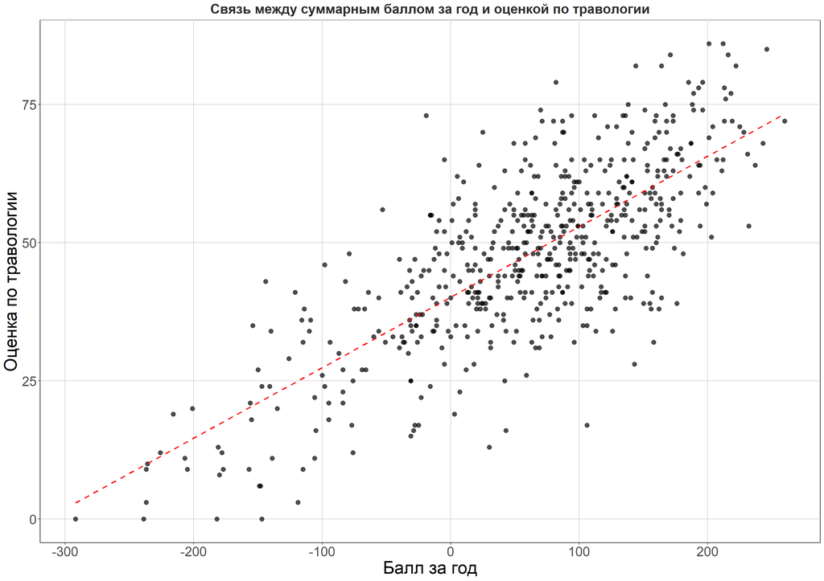

```r
ggplot(data, aes(x=result, y=`Herbology exam`)) +
  geom_point(size = 3, alpha = 0.7) +
  labs(x="Балл за год", y="Оценка по травологии",
       title = "Связь между суммарным баллом за год и оценкой по травологии") +
  geom_smooth(method="lm", se = FALSE, color = "red", linetype = "dashed") +
  theme_custom
```

Интерпретация: Судя по графику, есть положительная корреляция между суммарным баллом за год и оценкой по травологии. Это означает, что студенты с более высокой оценкой по травологии, как правило, имеют более высокий итоговый балл.

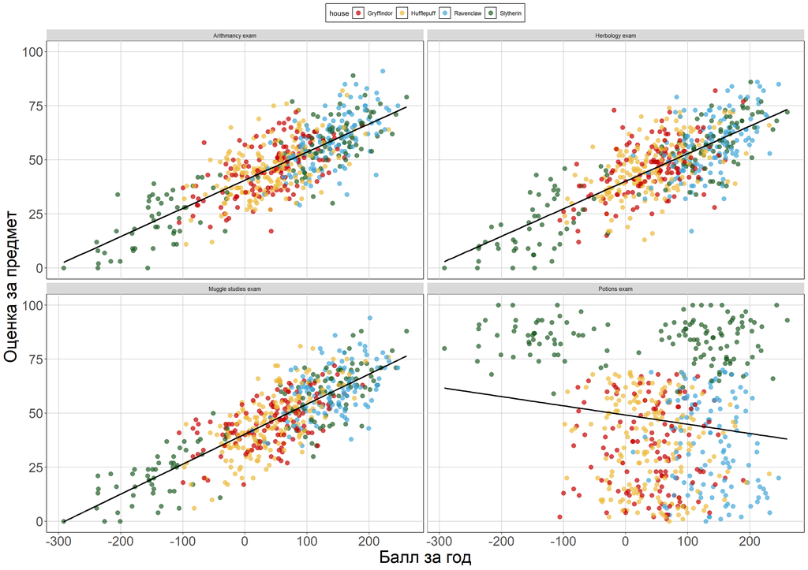

```r
data_long <- data %>%
  select(id, result, house, `Herbology exam`, `Muggle studies exam`, `Potions exam`, `Arithmancy exam`) %>%
  pivot_longer(cols = c(`Herbology exam`, `Muggle studies exam`, `Potions exam`, `Arithmancy exam`),
               names_to = "exam", values_to = "exam_result")

ggplot(data_long, aes(x = result, y = exam_result, color = house)) +
  geom_point(alpha = 0.7, size = 3) +
  geom_smooth(aes(group=1), method = "lm", se = FALSE, linetype = "solid", color = "black") +
  facet_wrap(~ exam, nrow = 2, ncol = 2) +
  scale_color_manual(values = c("Gryffindor" = "#C50000",
                                "Hufflepuff" = "#ECB939",
                                "Ravenclaw" = "#41A6D9",
                                "Slytherin" = "#1F5D25")) +
  labs(x = "Балл за год", y = "Оценка за предмет") +
  theme_custom
```

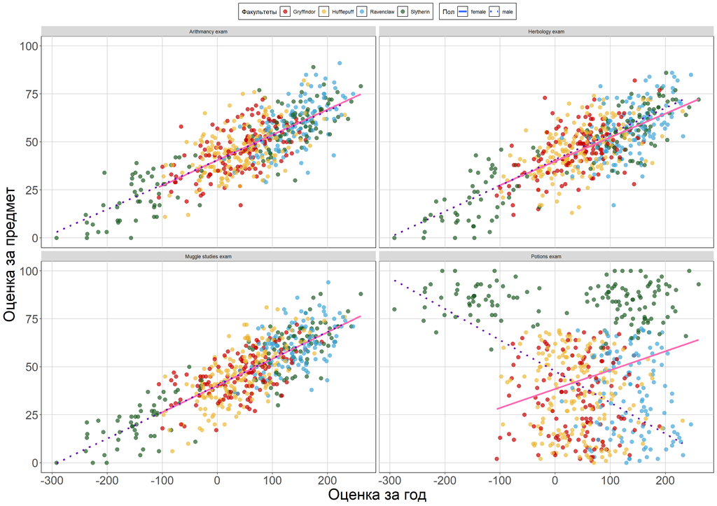

```r
data_with_sex <- data %>%
  select(id, result, house, sex, `Herbology exam`, `Muggle studies exam`, `Potions exam`, `Arithmancy exam`) %>%
  pivot_longer(cols = c(`Herbology exam`, `Muggle studies exam`, `Potions exam`, `Arithmancy exam`), names_to = "exam", values_to = "exam_result")

ggplot(data_with_sex, aes(x = result, y = exam_result)) +
  geom_point(aes(color = house), alpha = 0.7, size = 3) +
  geom_smooth(aes(group = sex, linetype = sex, color = sex), method = "lm", se = FALSE, size = 1.5) +
  facet_wrap(~ exam, nrow = 2, ncol = 2) +
  scale_color_manual(name = "Факультеты",
                     values = c("Gryffindor" = "#C50000",
                                "Hufflepuff" = "#ECB939",
                                "Ravenclaw" = "#41A6D9",
                                "Slytherin" = "#1F5D25",
                                "female" = "#ff69b4",
                                "male" = "#6a0dad"),
                     breaks = c("Gryffindor", "Hufflepuff", "Ravenclaw", "Slytherin")) +
  scale_linetype_manual(name = "Пол", values = c("female" = "solid", "male" = "dotted")) +
  labs(x = "Оценка за год", y = "Оценка за предмет") +
  theme_custom +
  guides(color = guide_legend(order = 1), linetype = guide_legend(order = 2))
```

## geom_col и вещи вокруг него

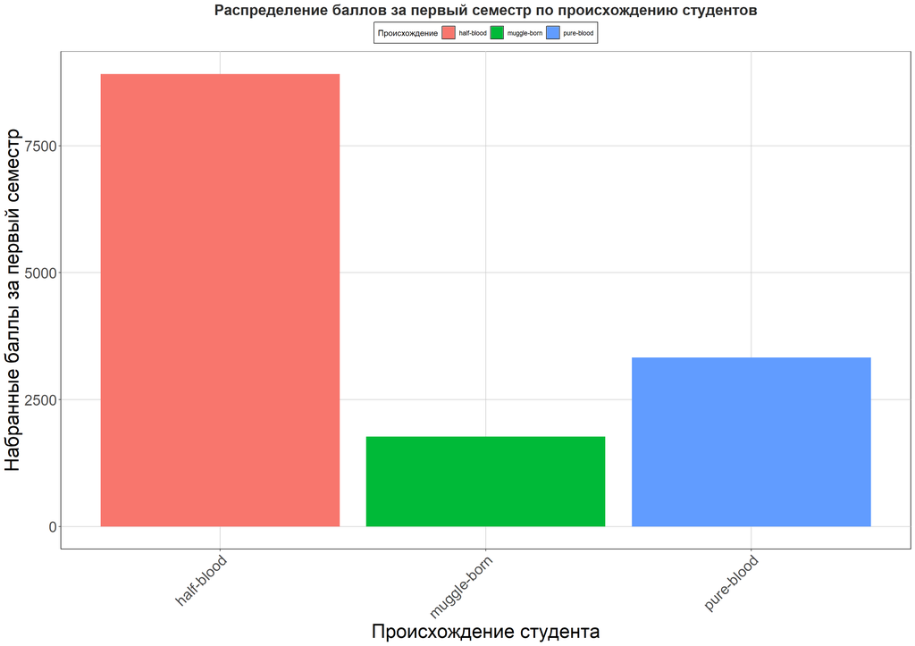

```r
data %>%
  group_by(bloodStatus) %>%
  summarise(total_semester1 = sum(c_across(week_1:week_17))) %>%
  ggplot(aes(x = bloodStatus, y = total_semester1, fill = bloodStatus)) +
  geom_col() +
  labs(x = "Происхождение студента", y = "Набранные баллы за первый семестр",
       title = "Распределение баллов за первый семестр по происхождению студентов",
       fill = "Происхождение") +
  theme_custom +
  theme(axis.text.x = element_text(angle = 45, hjust = 1))
```

Интерпретация: Вероятно, что магическое происхождение может влиять на магическо-академические способности студентов, однако вполне возможно, что тут играет роль и количество студентов (полукровок и чистокровных просто количественно больше, чем маглорожденных). Если среди полукровок больше всего студентов, то они, скорее всего, будут иметь наибольшие суммарные баллы, просто потому что каждый студент вносит свой вклад в эту сумму.

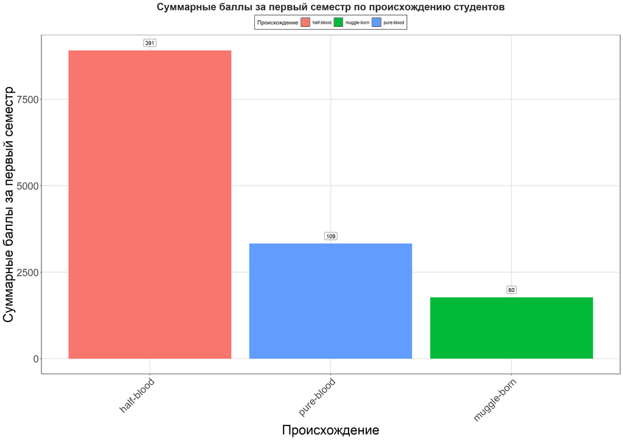

```r
data %>%
  group_by(bloodStatus) %>%
  summarise(total_semester1 = sum(c_across(week_1:week_17)), student_count = n()) %>%
  ggplot(aes(x = reorder(bloodStatus, -total_semester1), y = total_semester1, fill = bloodStatus)) +
  geom_col() +
  geom_label(aes(label = student_count), vjust = -0.5, fill = "white", color = "black") +
  labs(x = "Происхождение", y = "Суммарные баллы за первый семестр",
       title = "Суммарные баллы за первый семестр по происхождению студентов",
       fill = "Происхождение") +
  theme_custom +
  theme(axis.text.x = element_text(angle = 45, hjust = 1))
```

Интерпретация: наша гипотеза подтвердилась. На суммарные баллы повлияло количество студентов.

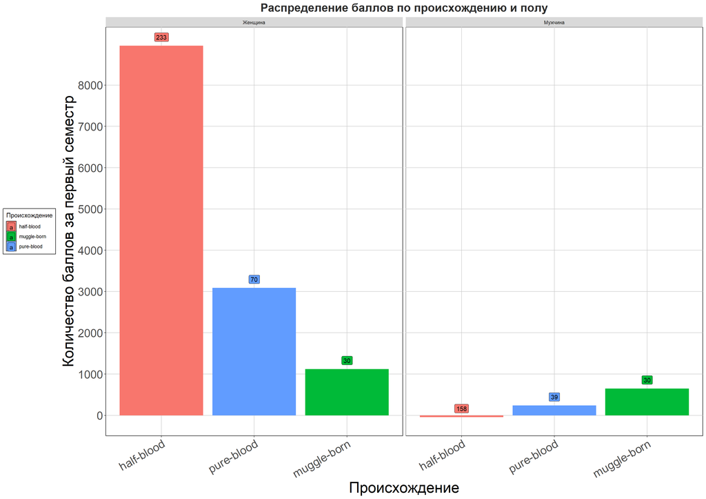

```r
grouped_data <- data %>%
  group_by(bloodStatus, sex) %>%
  summarise(total_semester1 = sum(c_across(week_1:week_17)), student_count = n(), .groups = 'drop')

plot <- grouped_data %>%
  ggplot(aes(x = reorder(bloodStatus, -total_semester1), y = total_semester1, fill = bloodStatus)) +
  geom_col(position = "dodge") +
  geom_label(aes(label = student_count), position = position_dodge(0.9), vjust = -0.5) +
  labs(title = "Распределение баллов по происхождению и полу",
       x = "Происхождение",
       y = "Количество баллов за первый семестр",
       fill = "Происхождение") +
  facet_wrap(~sex, labeller = as_labeller(c("male" = "Мужчина", "female" = "Женщина"))) +
  scale_y_continuous(breaks = seq(0, max(grouped_data$total_semester1), by = 1000)) +
  theme_custom +
  theme(axis.text.x = element_text(angle = 30, hjust = 1), legend.position = "left")


ggsave('Sex_bloodstatus.png', plot=plot, dpi = 300, width = 15, height=10)


plot
```

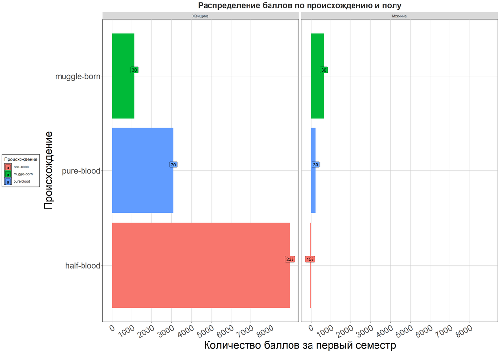

```r
plot <- grouped_data %>%
  ggplot(aes(x = reorder(bloodStatus, -total_semester1), y = total_semester1, fill = bloodStatus)) +
  geom_col(position = "dodge") +
  geom_label(aes(label = student_count), position = position_dodge(0.9), vjust = -0.5) +
  labs(title = "Распределение баллов по происхождению и полу",
       x = "Происхождение",
       y = "Количество баллов за первый семестр",
       fill = "Происхождение") +
  facet_wrap(~sex, labeller = as_labeller(c("male" = "Мужчина", "female" = "Женщина"))) +
  scale_y_continuous(breaks = seq(0, max(grouped_data$total_semester1), by = 1000)) +
  theme_custom +
  theme(axis.text.x = element_text(angle = 30, hjust = 1), legend.position = "left") +
  coord_flip()

plot
```

Интерпретация: фунция coord_flip() позволяет менять местами оси X и Y, преобразуя график из вертикального вида в горизонтальный. Думаю, что это полезно в случаях, когда категории на оси X имеют длинные подписи или их много, что делает их трудными для чтения. В таком случае горизонтальный график может быть более читабельным и аккуратным. Из минусов увидел трудность визуального воспринятия графика и необычный вид, что скорее всего будет просто непривычно видеть.

## Разное

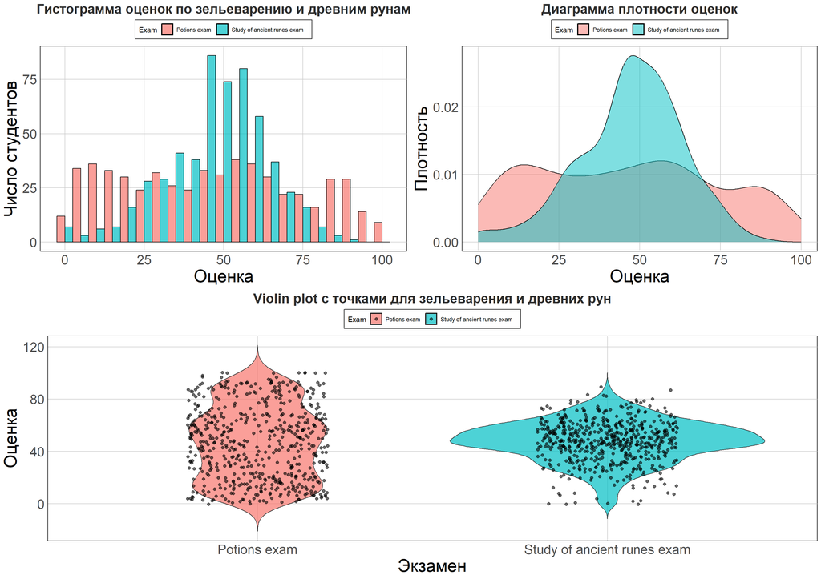

```r
data_long <- data %>%
  select(id, `Potions exam`, `Study of ancient runes exam`) %>%
  pivot_longer(cols = -id, names_to = "Exam", values_to = "Score")

plot_hist <- ggplot(data_long, aes(x = Score, fill = Exam)) +
  geom_histogram(binwidth = 5, alpha = 0.7, color = "black", position = "dodge") +
  labs(title = "Гистограмма оценок по зельеварению и древним рунам", x = "Оценка", y = "Число студентов") +
  theme_minimal() +
  theme_custom


plot_density <- ggplot(data_long, aes(x = Score, fill = Exam)) +
  geom_density(alpha = 0.5) +
  labs(title = "Диаграмма плотности оценок", x = "Оценка", y = "Плотность") +
  theme_minimal() +
  theme_custom

plot_violin <- ggplot(data_long, aes(x = Exam, y = Score, fill = Exam)) +
  geom_violin(trim = FALSE, alpha = 0.7) +
  geom_jitter(width = 0.2, alpha = 0.6, size = 2, color = "black") +
  labs(title = "Violin plot с точками для зельеварения и древних рун", x = "Экзамен", y = "Оценка") +
  theme_minimal() +
  theme_custom


combined_plot <- ggarrange(
  ggarrange(plot_hist, plot_density, ncol = 2),
  plot_violin,
  nrow = 2,
  heights = c(1, 1)
)

combined_plot
```

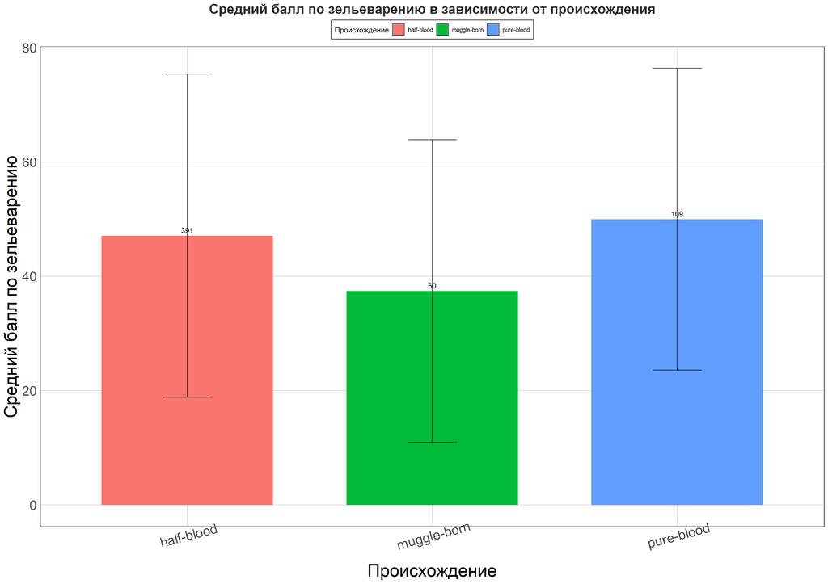

```r
avg_potions <- data %>%
  select(id, `Potions exam`, bloodStatus) %>%
  group_by(bloodStatus) %>%
  summarise(mean_score = mean(`Potions exam`, na.rm = TRUE),
            sd_score = sd(`Potions exam`, na.rm = TRUE),
            n = n())

plot_potions <- ggplot(avg_potions, aes(x = bloodStatus, y = mean_score, fill = bloodStatus)) +
  geom_bar(stat = "identity", width = 0.7) +
  geom_errorbar(aes(ymin = mean_score - sd_score, ymax = mean_score + sd_score), width = 0.2) +
  geom_text(aes(label = n), vjust = -0.5) +
  labs(title = "Средний балл по зельеварению в зависимости от происхождения",
       x = "Происхождение",
       y = "Средний балл по зельеварению",
       fill = "Происхождение") +
  guides(fill = guide_legend(title = "Происхождение")) +  # Легенда будет автоматически
  theme_minimal() +
  theme_custom +
  theme(axis.text.x = element_text(angle = 15))

plot_potions
```

Можно предположить, что чистокровные и полукровки могли получить более глубокие знания по магическим предметам, таким как зельеварение, ещё до поступления в школу, поскольку они могли иметь доступ к магическим ресурсам в своей семье, либо это обычная дискриминация по отношению к маглорожденным, т.к. известно, что зельеварение вел Снегг до 6 курса. Чтобы проверить это, сравним средние баллы студентов разного происхождения с другими предметами (например, по рунам и по травологии)

```r
avg_subjects <- data %>%
  select(id, `Study of ancient runes exam`, `Herbology exam`, bloodStatus) %>%
  pivot_longer(cols = c(`Study of ancient runes exam`, `Herbology exam`),
               names_to = "Subject", values_to = "Score") %>%
  group_by(bloodStatus, Subject) %>%
  summarise(mean_score = mean(Score, na.rm = TRUE),
            sd_score = sd(Score, na.rm = TRUE),
            n = n()) %>%
  mutate(bloodStatus = fct_relevel(bloodStatus,"Muggle-born", "Pure-blood", "Half-blood"))
```

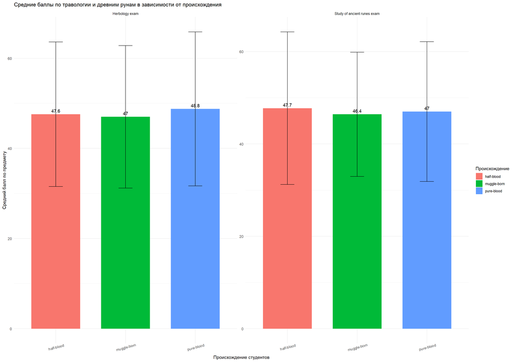

```r
plot_subjects <- ggplot(avg_subjects, aes(x = bloodStatus, y = mean_score, fill = bloodStatus)) +
  geom_bar(stat = "identity", width = 0.7) +
  geom_errorbar(aes(ymin = mean_score - sd_score, ymax = mean_score + sd_score), width = 0.2) +
  geom_text(aes(label = round(mean_score, 1)), vjust = -0.5) +
  labs(title = "Средние баллы по травологии и древним рунам в зависимости от происхождения",
       x = "Происхождение студентов",
       y = "Средний балл по предмету",
       fill = "Происхождение") +
  guides(fill = guide_legend(title = "Происхождение")) +
  facet_wrap(~ Subject, scales = "free_y") +
  theme_minimal() +
  theme(axis.text.x = element_text(angle = 15))

plot_subjects
```

Наша гипотеза подтвердилась! Маглорожденных просто недолюбливают на зельеварении. Средние баллы по двум другим предметам практически не отличаются среди студентов разного происхождения.

## Дополнительное задание

```r
data <- data %>%
  mutate(house = fct_relevel(house, "Gryffindor", "Hufflepuff", "Ravenclaw", "Slytherin"))
colnames(data)
```

```
##  [1] "id"                                 "house"
##  [3] "course"                             "sex"
##  [5] "wandCore"                           "bloodStatus"
##  [7] "result"                             "Defence against the dark arts exam"
##  [9] "Flying exam"                        "Astronomy exam"
## [11] "Herbology exam"                     "Divinations exam"
## [13] "Charms exam"                        "History of magic exam"
## [15] "Arithmancy exam"                    "Care of magical creatures exam"
## [17] "Muggle studies exam"                "Study of ancient runes exam"
## [19] "Transfiguration exam"               "Potions exam"
## [21] "week_1"                             "week_2"
## [23] "week_3"                             "week_4"
## [25] "week_5"                             "week_6"
## [27] "week_7"                             "week_8"
## [29] "week_9"                             "week_10"
## [31] "week_11"                            "week_12"
## [33] "week_13"                            "week_14"
## [35] "week_15"                            "week_16"
## [37] "week_17"                            "week_18"
## [39] "week_19"                            "week_20"
## [41] "week_21"                            "week_22"
## [43] "week_23"                            "week_24"
## [45] "week_25"                            "week_26"
## [47] "week_27"                            "week_28"
## [49] "week_29"                            "week_30"
## [51] "week_31"                            "week_32"
## [53] "week_33"                            "week_34"
## [55] "week_35"                            "week_36"
## [57] "week_37"                            "week_38"
## [59] "week_39"                            "week_40"
```

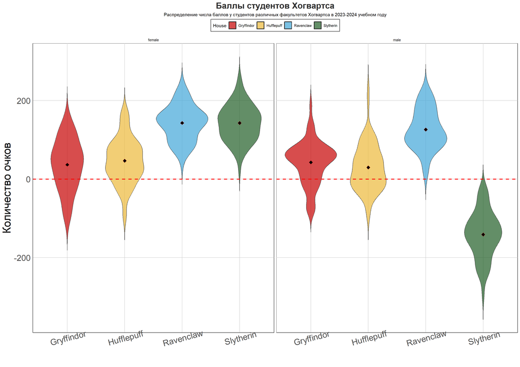

```r
ggplot(data, aes(x = house, y = result, fill = house)) +
  geom_violin(trim = FALSE, alpha = 0.7) +
  stat_summary(fun = mean, geom = "point", shape = 23, size = 3, fill = "black", color = "red") +
  geom_hline(yintercept = 0, linetype = "dashed", color = "red", size = 1) +
  facet_grid(~ sex) +
  scale_fill_manual(values = c("Gryffindor" = "#C50000",
                               "Hufflepuff" = "#ECB939",
                               "Ravenclaw" = "#41A6D9",
                               "Slytherin" = "#1F5D25")) +
  labs(title = "Баллы студентов Хогвартса",
       subtitle = "Распределение числа баллов у студентов различных факультетов Хогвартса в 2023-2024 учебном году",
       x = "",
       y = "Количество очков",
       fill = "House") +
  theme_minimal() +
  theme_custom +
  theme(axis.text.x = element_text(angle = 15),
        plot.subtitle = element_text(hjust = 0.5))
```